[figure not shown]

# **Report LabRI Tool (v5.5.3)**

Estimation and verification of reference interval by the LabRI tool.

Date of the last compilation: 19/10/2026 (BR) | 2026-10-19 (ISO)

The **LabRI tool** is an R Markdown file that employs the indirect method called the **LabRI Method**. This method is an adaptive and multi-criteria approach for the estimation and verification of reference intervals, utilizing a combination of data cleaning algorithms, data transformation, clustering techniques, and the refineR and reflimR algorithms or the expectation-maximization (EM) algorithm, depending on the number of clusters in the truncated distribution.

#### **Copyright (C); 2026; LabR Group**

This program is free software: you can redistribute it and/or modify it under the terms of the GNU General Public License as published by the Free Software Foundation, either version 3 of the License, or (at your option) any later version.

This program is distributed in the hope that it will be useful, but WITHOUT ANY WARRANTY; without even the implied warranty of MERCHANTABILITY or FITNESS FOR A PARTICULAR PURPOSE. See the GNU General Public License for more details.

You should have received a copy of the GNU General Public License along with this program. If not, see [Link](https://www.gnu.org/licenses/).

# Contents

## 1. Initial information

**Table 1.** Installation and loading status of the required R packages.

| AID | DT | grid | lubridate | nortest | reflimR | tidyr |
| --- | --- | --- | --- | --- | --- | --- |
| TRUE | TRUE | TRUE | TRUE | TRUE | TRUE | TRUE |
| callr | epiR | gt | MASS | openxlsx | rmarkdown | tools |
| TRUE | TRUE | TRUE | TRUE | TRUE | TRUE | TRUE |
| calibrate | factoextra | imputeTS | matrixStats | pandoc | RVAideMemoire | univOutl |
| TRUE | TRUE | TRUE | TRUE | TRUE | TRUE | TRUE |
| cartography | FactoMineR | installr | mclust | patchwork | scales | utf8 |
| TRUE | TRUE | TRUE | TRUE | TRUE | TRUE | TRUE |
| cluster | ffp | irr | MethComp | plotly | shiny | writexl |
| TRUE | TRUE | TRUE | TRUE | TRUE | TRUE | TRUE |
| data.table | forecast | janitor | mixR | prettydoc | shinyjs | xfun |
| TRUE | TRUE | TRUE | TRUE | TRUE | TRUE | TRUE |
| datawizard | future.apply | kableExtra | modeest | qqplotr | shinythemes | zlog |
| TRUE | TRUE | TRUE | TRUE | TRUE | TRUE | TRUE |
| devtools | ggplot2 | KernSmooth | moments | readr | stats |  |
| TRUE | TRUE | TRUE | TRUE | TRUE | TRUE |  |
| digest | ggpubr | knitr | multimode | readxl | stringi |  |
| TRUE | TRUE | TRUE | TRUE | TRUE | TRUE |  |
| dplyr | ggtext | lattice | multiway | refineR | systemfonts |  |
| TRUE | TRUE | TRUE | TRUE | TRUE | TRUE |  |

**Responsible person:** Alan Carvalho Dias;

**Measurement procedure and Method:** Beckman Coulter AU 5800 (Brea, California, US); 2-chloro-4-nitrophenyl-α-D-maltotrioside;

**Name of the measurand:** AMY;

**Unit of measurement:** U/L;

**Type of blood specimen:** serum;

**Exclusion criteria:** Exclusion criteria included individuals with a body mass index (BMI) >35 kg/m2, consumption of ethanol >= 70 g per day, smoking >20 cigarettes per day, taking regular medication for a chronic disease (diabetes mellitus, hypertension, hyperlipidemia, allergic disorders, depression), recent (< 15 days) recovery from acute illness, injury or surgery requiring hospitalization, carrier of HBV, HCV or HIV, pregnant or within 1 year after delivery. Written informed consent was obtained after written/verbal explanation of the study. Those with any chronic disease were excluded except for individuals aged 50–65 years who had well controlled hypertension taking up to 2 drugs. A single measurement of blood pressure, abdominal circumference and BMI was done after filling the study questionnaire. As a measure for secondary exclusion of abnormal values, we tried to apply LAVE in deriving the RI both by parametric and nonparametric methods;

**Data source:** Recruitment of study participants in Kenya was carried out between January and October 2015 in several counties. Majority were urban dwellers from the capital city Nairobi, Kiambu county in central Kenya, Kisii County in western Kenya, and Nakuru County based in the Great Rift Valley. Obtained from the dataset of the study by Omuze et al., available in the Dryad repository: https://doi.org/10.5061/DRYAD.NVX0K6DNS;

**Age range:** 18 to 65 years;

**Sex:** Male and Female;

**Settings:**

- **Number of decimal places:** 0;
- **Setting the limits of the Reference Interval (‘Double-sided’ or ‘One-sided’):** Double-sided. There is a Lower Limit and an Upper Limit of reference.;

## 2. Descriptive statistics

[output not shown]

[output cut: 523 more lines]

**Table 3.** Measures of Position - Part 1.

| Statistical parameters | Results |
| --- | --- |
| N | 533 |
| n | 533 |
| Minimum | 27 |
| Mode | 84.9 |
| Mean | 91.7 |
| Median | 86 |
| Maximum | 327 |

Footnote  
**N**, total sample size in the original dataset (before subsampling and outlier removal). **n**, number of observations effectively selected for analysis after subsampling.

**Table 4.** Measures of Position - Part 2.

| Statistical parameters | Results |
| --- | --- |
| N | 533.0 |
| n | 533.0 |
| 1st percentile | 40.6 |
| 2.5th percentile | 46.3 |
| 5th percentile | 52.0 |
| 10th percentile | 56.0 |
| 16th percentile | 62.0 |
| 25th percentile | 69.0 |
| 50th percentile (median) | 86.0 |
| 75th percentile | 107.0 |
| 84th percentile | 118.0 |
| 90th percentile | 131.0 |
| 95th percentile | 152.2 |
| 97.5th percentile | 172.7 |
| 99th percentile | 194.8 |

Footnote  
**N**, total sample size in the original dataset (before subsampling and outlier removal). **n**, number of observations effectively selected for analysis after subsampling.

**Table 5.** Measures of Dispersion.

| Statistical parameters | Results |
| --- | --- |
| N | 533 |
| n | 533 |
| SD | 33.2 |
| Variance | 1101.5 |
| IQR | 38 |
| Range | 300 |

Footnote  
**N**, total sample size in the original dataset (before subsampling and outlier removal). **n**, number of observations effectively selected for analysis after subsampling. **SD**, Standard Deviation. **IQR**, Interquartile Range.

## 3. Estimation Module

- The LabRI method is an adaptive and multi-criteria approach for the **indirect estimation and verification** of reference intervals. It integrates data cleaning, data transformation, clustering techniques, and applies the refineR, reflimR, and Expectation-Maximization (EM) algorithms. The method combines parametric and non-parametric percentile approaches to estimate population reference intervals, depending on the number of clusters identified in the truncated distribution.

**Characteristics of the LabRI Method:**

- **Adaptive:** Adjusts its application based on the structure and characteristics of the data, using different cleaning and transformation techniques as needed. Applies the Centroid of Windsorized Reference Limits method using refineR and reflimR if the data distribution has more than one cluster for reference interval estimation. If there is only one cluster, the expectation-maximization algorithm is used with both parametric and non-parametric approaches to obtain the best reference interval estimate.
- **Multi-criteria:** Considers multiple criteria and methods for the estimation and verification of reference intervals, ensuring a robust and comprehensive analysis.

### 3.1. Initial data preprocessing

**3.1.1. Handling Rounding Artifacts for Reliable Mixture-Model Fitting**

Prior to Expectation–Maximization (EM) mixture modeling with the `mclust` and `mixR` packages, a reproducible uniform micro-jitter (IFCC-style dithering) is applied to break ties **(eq.1)** [1]. This step preserves analytical resolution while improving numerical stability during model fitting, because extensive ties and heavy rounding can impair EM-based Gaussian mixture estimation, increasing the risk of degenerate covariance estimates and convergence failures. The perturbed values are then truncated downward to d+2 decimal places. Finally, any values that become zero or negative after jittering are replaced with a small positive floor (0.0001) [[2]](https://doi.org/10.1002/cpt.2603).

$$\Large{
x_i^{\ast} = x_i + 10^{-(d+1)}\times (r_i - 0.5)
}\qquad (eq.1)$$

where, **d**, denotes the number of decimal places used to report the original measurements. **x<sub>i</sub>**, is the individual laboratory test result. **r<sub>i</sub>**, is a computer-generated random number between 0.0 and 1.0. **x<sub>i</sub>***, is the jittered value obtained after applying the uniform micro-jitter to the original result x<sub>i</sub>

**3.1.2. Box-Cox transformation approaches:**

- The Box-Cox transformation is applied based on the **Bowley's Coefficient of Skewness (Sk<sub>Bowley</sub>)**. After the transformation, Sk<sub>Bowley</sub> is reassessed to determine which dataset exhibits a distribution closest to Gaussian. The dataset with the most Gaussian-like profile, whether from the cleaned original data or the transformed data, will be used in the clustering and truncation steps.

**3.1.2. Algorithm for data transformation:**

- The LabRI method uses a **transformation algorithm** to select the optimal Box-Cox transformation based on the **log-likelihood criterion**. The report presents both the lambda value (λ) obtained according to the refineR criterion and the λ value selected by the LabRI decision rule, which is used to decide whether transformation should be applied in downstream reference-interval estimation by reflimR and by LabRI itself.
- The transformation of y is performed using **eq.(2)**:

$$\Large{
y_i^{(\lambda)} =
\left\{
\begin{matrix}
{\frac{y_i^\lambda - 1}{\lambda}}, & \mbox{if } \lambda \neq 0 \\
ln(y_i), & \mbox{if } \lambda = 0
\end{matrix}
\right.
} \quad \quad \quad \quad \quad \quad {(2)}$$
where, **$y^{(\lambda)}$**, the transformed value of the (i)-th observation after applying the Box-Cox transformation. **$y_{i}$**, the original value of the $i$-th observation in the dataset. **$\lambda$**, the transformation parameter that maximizes the normality of the data. It is determined through optimization. **$ln(y_{i})$**, the natural logarithm of $y_{i}$, used when $\lambda = 0$.

**3.1.2. Interpreting the shape of data distributions**

- **Skewness** refers to a distortion or asymmetry that deviates from the symmetrical bell curve, or normal distribution, in a set of data. If the curve is shifted to the left or right, it is said to be skewed.
  - **Positive skewed distribution (or right-skewed distribution):** It is a type of distribution in which most values are clustered around the left tail of the distribution, while the right tail of the distribution is longer, indicating a positive skewness coefficient (Sk > 0).
  - **Negative skewness (or left-skewed distribution):** It is a type of distribution in which most of the values are grouped around the right tail of the distribution, while the left tail of the distribution is longer, indicating a negative skewness coefficient (Sk < 0).
- **Kurtosis:** Similar to ‘skewness’, kurtosis coefficient (Kt) is a statistical measure used to describe a distribution. While skewness differentiates extreme values in one tail versus the other, kurtosis measures extreme values in both tails. Kurtosis is a measure of the combined weight of the tails of a distribution relative to the center of the distribution.
  - **Leptokurtic:** A leptokurtic distribution shows heavy tails on both sides, indicating large discrepant values. Theoretically, a leptokurtic distribution is one with K > 3. From a practical standpoint, a leptokurtic distribution with Kt > 3.3 can be considered visibly or perceptibly leptokurtic.
  - **Mesokurtic:** Data that follows a mesokurtic distribution shows an excess kurtosis of zero or close to zero. This means that if the data follows a normal distribution, it follows a mesokurtic distribution. Theoretically, the kurtosis of a normal distribution is equal to 3. A distribution of results between 2.7 and 3.3 will be considered mesokurtic.
  - **Platykurtic:** The kurtosis reveals a distribution with flattened tails. The flat tails indicate few outliers in the distribution. Theoretically, a platykurtic distribution is one with kurtosis below 3. From a practical standpoint, a distribution with kurtosis below 2.7 can be considered platykurtic.

**Table 6.** Data-cleaning summary and Box–Cox transformation decision metrics.

| Statistics parameters | Results |
| --- | --- |
| N | 533 |
| n | 533 |
| Detection of outliers based on Box Plot | 2 |
| Percentage of outliers detected and removed | 0.4 |
| n<sub>New1</sub> | 531 |
| **Sk<sub>Pearson<sub>orig</sub></sub>** | 1.611 |
| Sk<sub>Bowley<sub>orig</sub></sub> | 0.149 |
| Sk<sub>Bowley<sub>trans</sub></sub> | 0.064 |
| **\|Δ<sub>Sk</sub>\|** | 0.085 |
| Box–Cox decision | The Box–Cox transformation was applied to the data using a λ<sub>LabRI</sub> value of 0 . |

Footnote  
**N**, total sample size in the original dataset (before subsampling and outlier removal). **n**, number of observations effectively selected for analysis after subsampling. **n<sub>New1</sub>**, remaining sample size after outlier removal (number of observations retained for downstream analysis). **Sk<sub>Pearson<sub>orig</sub></sub>**, Pearson’s coefficient of skewness for the original data. **Sk<sub>Bowley</sub>**, Bowley’s Coefficient of Skewness. **Sk<sub>Bowley<sub>orig</sub></sub>**, Bowley’s Coefficient of Skewness for the original data. **Sk<sub>Bowley<sub>trans</sub></sub>**, Bowley’s Coefficient of Skewness for the transformed data. **|Δ<sub>Sk</sub>|**, the absolute difference in the Sk<sub>Bowley</sub> values between the original and transformed data. **Box–Cox decision rule:** transformation is skipped if Sk<sub>Pearson<sub>orig</sub></sub> ∈ [−0.15, 0.15] or Sk<sub>Bowley<sub>orig</sub></sub> ∈ [−0.025, 0.025]; otherwise, Box-Cox transformation is applied only if the transformed data show lower absolute Bowley skewness than the original data and |Δ<sub>Sk</sub>| > 0.05. **Reference:** [[3]](https://doi.org/10.1093/clinchem/47.12.2137), [[4]](https://doi.org/10.32614/CRAN.package.reflimR), [[5]](https://doi.org/10.32614/CRAN.package.univOutl), [[6]](https://doi.org/10.1007/s41060-024-00559-0)

#### 3.1.1. Data shape before cleaning

- Distribution profile of data **before the outlier removal** algorithm.

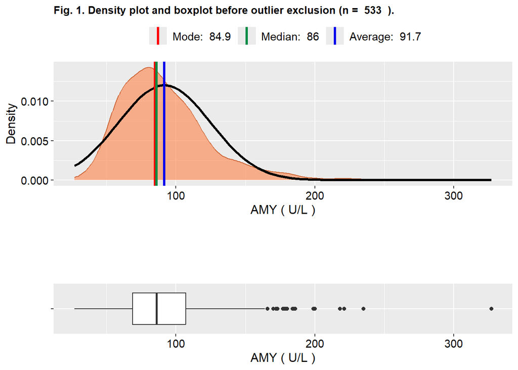

[interactive chart not shown]

**Table 7.** Data distribution before outlier detection and exclusion (n = 533 ).

| Statistical parameters | Results |
| --- | --- |
| N | 533 |
| n | 533 |
| Kt | 8.73 |
| Interpretation of the Kt | The distribution can be considered leptokurtic. |
| Sk<sub>Pearson</sub> | 1.61 |
| Interpreting the result of the Sk<sub>Pearson</sub> | Empirical relationship between Mean, Median, and Mode is: Mean > Median > Mode. The distribution is highly skewed to the right. |

Footnote  
**N**, total sample size in the original dataset (before subsampling and outlier removal). **n**, number of observations effectively selected for analysis after subsampling. **Kt**, Kurtosis coefficient. Sk<sub>Pearson</sub>, Pearson’s coefficient of skewness. **Mesokurtic:** If Kt is between 2.7 and 3.3, the distribution can be considered mesokurtic. **Platykurtic:** If Kt is less than 2.7. **Leptokurtic:** If Kt is greater than 3.3. **Distribution is highly skewed:** If Sk<sub>Pearson</sub> is less than -1 or greater than 1. **Distribution is moderately skewed:** If Sk<sub>Pearson</sub> is between -1 and -0.5 or between 0.5 and 1. **Distribution is slightly skewed:** If Sk<sub>Pearson</sub> is between -0.5 and -0.15 or between 0.15 and 0.5. **Distribution is approximately symmetrical:** If Sk<sub>Pearson</sub> is between -0.15 and 0.15. **References:** [[7]](https://doi.org/10.1515/CCLM.2010.319), [[8]](https://doi.org/10.1201/9781315153803), [[9]](https://doi.org/10.4103/aca.ACA_157_18), [[10]](https://doi.org/10.1016/j.clinbiochem.2019.06.006), [[11]](https://doi.org/10.1016/j.clinbiochem.2017.07.005)

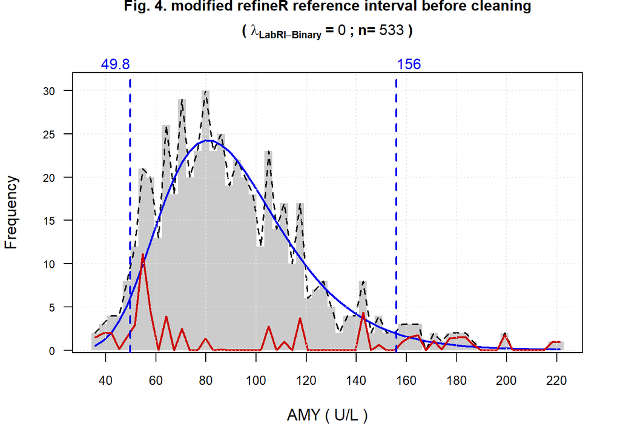

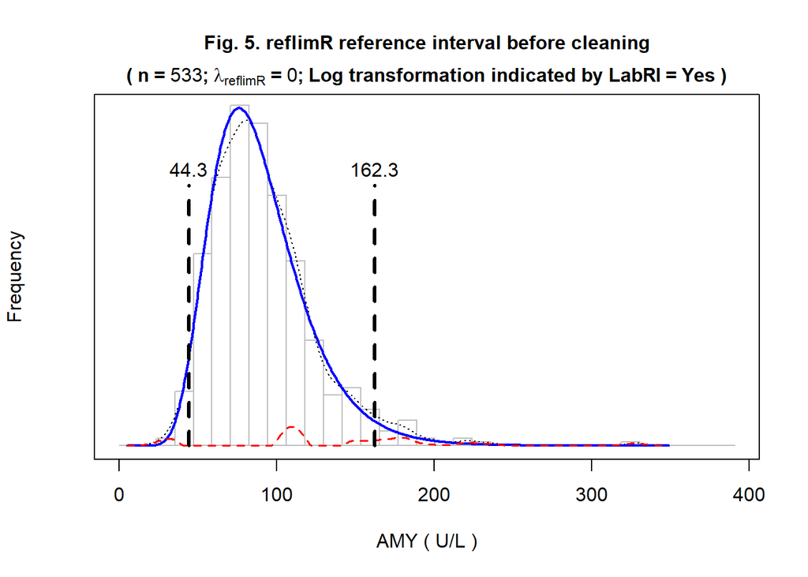

#### 3.1.2. Data shape after cleaning

- Distribution profile of the data **after the outlier removal** algorithm.

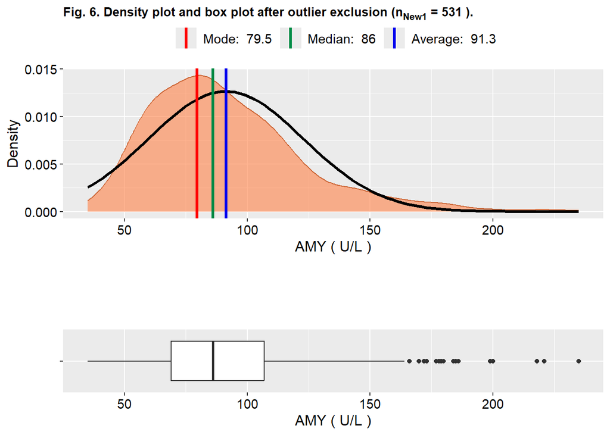

[interactive chart not shown]

**Table 8.** Data shape after outlier detection (n<sub>New1</sub> = 531 ).

| Statistical parameters | ResultS |
| --- | --- |
| N | 533 |
| n | 533 |
| n<sub>New1</sub> | 531 |
| Kt | 4.91 |
| Interpretation of the Kt | The distribution can be considered leptokurtic. |
| Sk<sub>Pearson</sub> | 1.15 |
| Interpreting the result of the Sk<sub>Pearson</sub> | Empirical relationship between Mean, Median, and Mode is: Mean > Median > Mode. The distribution is highly skewed to the right. |

Footnote  
**N**, total sample size in the original dataset (before subsampling and outlier removal). **n**, number of observations effectively selected for analysis after subsampling. **n<sub>New1</sub>**, remaining sample size after outlier removal (number of observations retained for downstream analysis).**Kt**, Kurtosis coefficient. Sk<sub>Pearson</sub>, Pearson’s coefficient of skewness. **Mesokurtic:** If Kt is between 2.7 and 3.3, the distribution can be considered mesokurtic. **Platykurtic:** If Kt is less than 2.7. **Leptokurtic:** If Kt is greater than 3.3. **Distribution is highly skewed:** If Sk<sub>Pearson</sub> is less than -1 or greater than 1. **Distribution is moderately skewed:** If Sk<sub>Pearson</sub> is between -1 and -0.5 or between 0.5 and 1. **Distribution is slightly skewed:** If Sk<sub>Pearson</sub> is between -0.5 and -0.15 or between 0.15 and 0.5. **Distribution is approximately symmetrical:** If Sk<sub>Pearson</sub> is between -0.15 and 0.15. **References:** [[7]](https://doi.org/10.1515/CCLM.2010.319), [[8]](https://doi.org/10.1201/9781315153803), [[9]](https://doi.org/10.4103/aca.ACA_157_18), [[10]](https://doi.org/10.1016/j.clinbiochem.2019.06.006), [[11]](https://doi.org/10.1016/j.clinbiochem.2017.07.005)

[figure not shown]

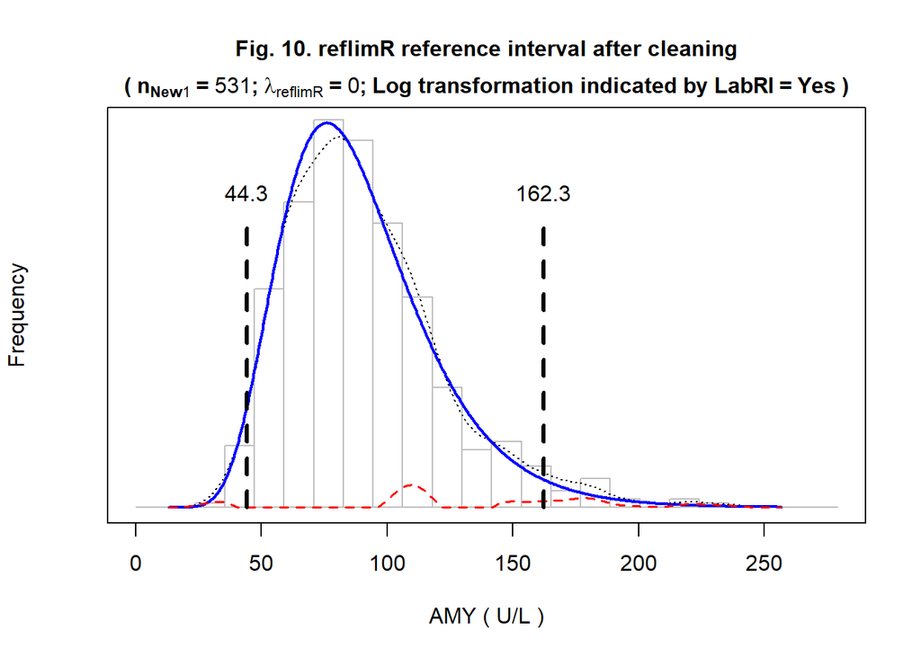

#### 3.1.3. Box-Cox transformation

The Box–Cox transformation was applied to the data using a λ<sub>LabRI</sub> value of 0 .

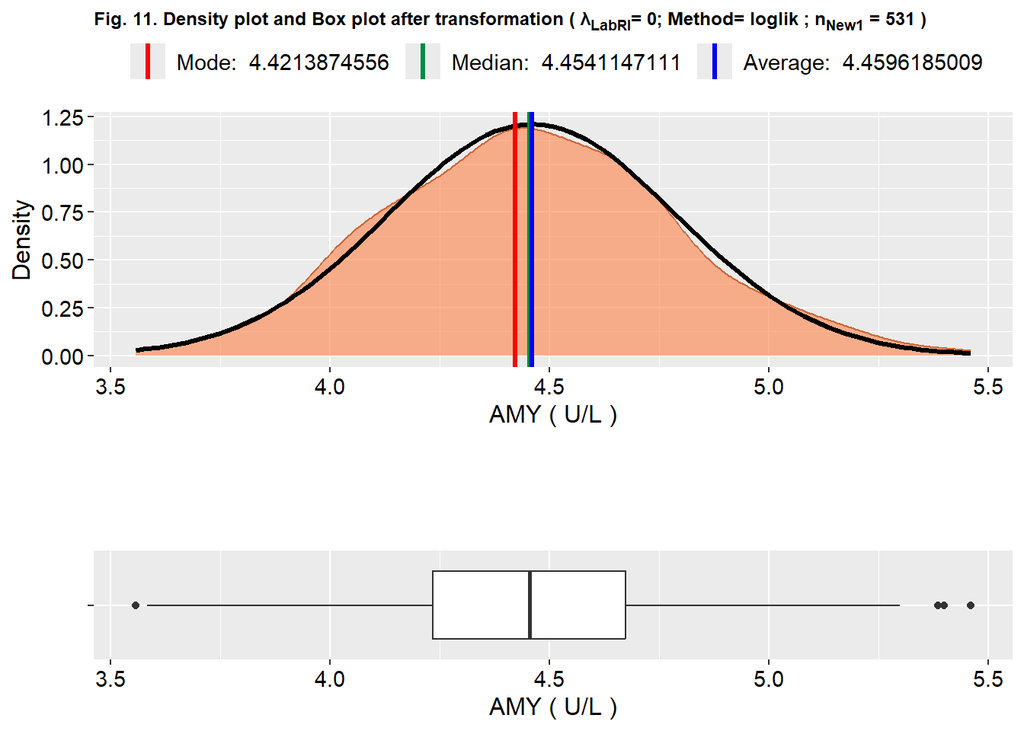

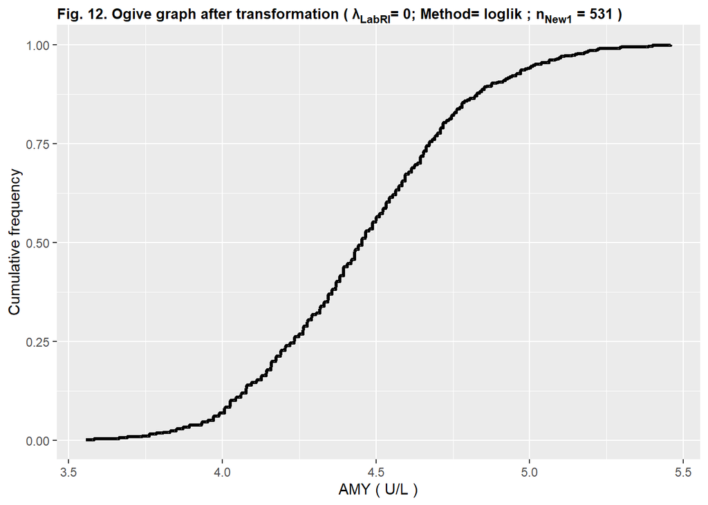

[interactive chart not shown]

**Table 9.** Shape of the data after transformation ( λ<sub>LabRI</sub>= 0; Method= loglik ; n<sub>New1</sub> = 531 ).

| Statistical parameters | ResultS |
| --- | --- |
| N | 533 |
| n | 533 |
| n<sub>New1</sub> | 531 |
| Kt | 2.93 |
| Interpretation of the Kt | The distribution can be considered mesokurtic. |
| Sk<sub>Pearson</sub> | 0.14 |
| Interpreting the result of the Sk<sub>Pearson</sub> | Empirical relationship between Mean, Median, and Mode is: Mean > Median > Mode. The distribution is approximately symmetric. |

Footnote  
**N**, total sample size in the original dataset (before subsampling and outlier removal). **n**, number of observations effectively selected for analysis after subsampling. **n<sub>New1</sub>**, remaining sample size after outlier removal (number of observations retained for downstream analysis).**Kt**, Kurtosis coefficient. Sk<sub>Pearson</sub>, Pearson’s coefficient of skewness. **Mesokurtic:** If Kt is between 2.7 and 3.3, the distribution can be considered mesokurtic. **Platykurtic:** If Kt is less than 2.7. **Leptokurtic:** If Kt is greater than 3.3. **Distribution is highly skewed:** If Sk<sub>Pearson</sub> is less than -1 or greater than 1. **Distribution is moderately skewed:** If Sk<sub>Pearson</sub> is between -1 and -0.5 or between 0.5 and 1. **Distribution is slightly skewed:** If Sk<sub>Pearson</sub> is between -0.5 and -0.15 or between 0.15 and 0.5. **Distribution is approximately symmetrical:** If Sk<sub>Pearson</sub> is between -0.15 and 0.15. **References:** [[7]](https://doi.org/10.1515/CCLM.2010.319), [[8]](https://doi.org/10.1201/9781315153803), [[9]](https://doi.org/10.4103/aca.ACA_157_18), [[10]](https://doi.org/10.1016/j.clinbiochem.2019.06.006), [[11]](https://doi.org/10.1016/j.clinbiochem.2017.07.005)

### 3.2. Clustering and truncation

**3.2.1. Clustering**

**Table 10.** Multicriteria cluster-number estimates and final consensus selection (nonparametric KDE modes, Gaussian-mixture BIC criteria, and low-count override) ( λ<sub>LabRI</sub>= 0; Method= loglik ; n<sub>New1</sub> = 531 ).

| Criterion Number | Criterion description | Estimated number of clusters |
| --- | --- | --- |
| Criterion 1 | Estimated the number of clusters by counting modes in a Gaussian-kernel KDE, using a 1.06 normal-reference bandwidth constant | 1 |
| Criterion 2 | Estimated the number of clusters by counting modes in a Gaussian-kernel KDE, using a 0.90 normal-reference bandwidth constant | 1 |
| Criterion 3 | Maximum BIC (V model: variable variance) | 1 |
| Criterion 4 | 80% cumulative BIC gain (V model: variable variance) | 1 |
| Criterion 5 | BIC-curve plateau / stabilization of gains (V model: variable variance) | 1 |
| Criterion 6 | Maximum BIC (E model: equal variance) | 1 |
| Criterion 7 | 80% cumulative BIC gain (E model: equal variance) | 1 |
| Criterion 8 | BIC-curve plateau / stabilization of gains (E model: equal variance) | 1 |
| Criterion 9 | Low-Count Datasets: a single cluster is assumed | N/A |
| Conclusion | Conservative multicriteria estimate: final number of clusters (integrating all criteria) | 1 |

Footnote  
**N/A**, not applicable. **n<sub>New1</sub>**, remaining sample size after outlier removal (number of observations retained for downstream analysis). **KDE**, Kernel Density Estimation. **BIC**, Bayesian Information Criterion. **E model**, Equal-variance Gaussian mixture model (component variances constrained to be equal). **V model**, Variable-variance Gaussian mixture model (component variances allowed to differ).

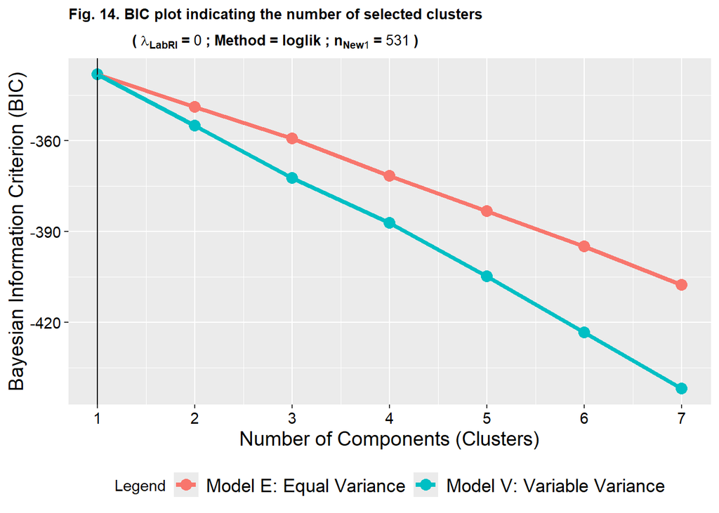

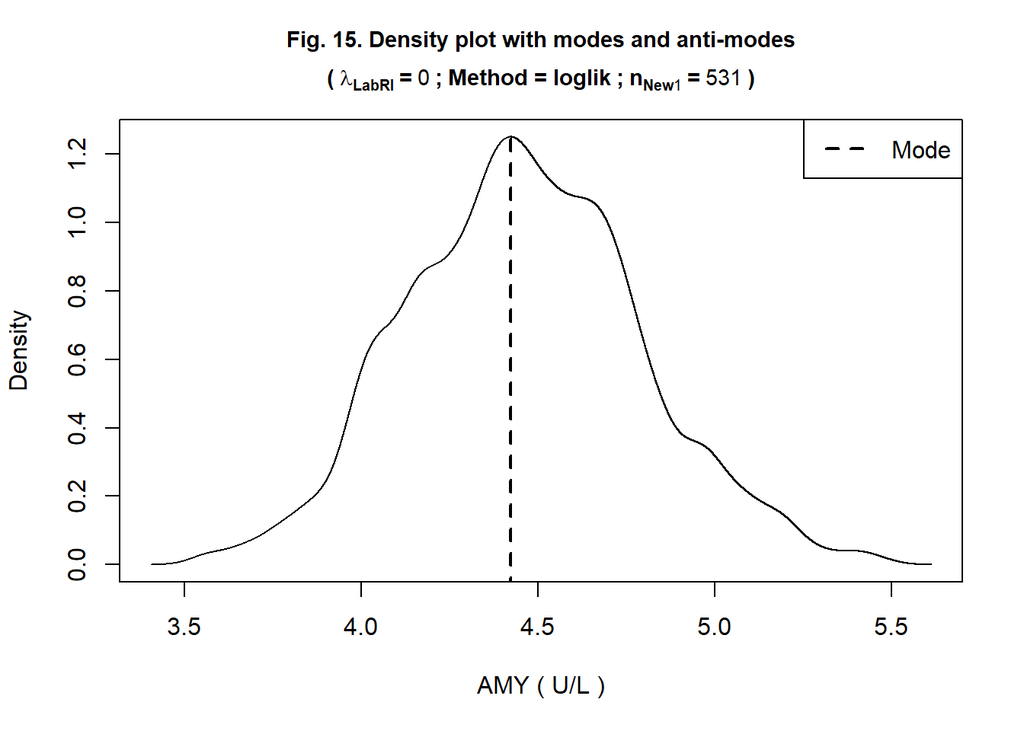

**Table 11.** Modes and anti-modes ( λ<sub>LabRI</sub>= 0; Method= loglik ; n<sub>New1</sub> = 531 ; bw<sub>critical</sub> = 0.0504 ).

| n<sub>Modes</sub> | Modes | Anti-modes |
| --- | --- | --- |
| 1 | 4.4213874556 | – |
| 2 | – | – |
| 3 | – | – |
| 4 | – | – |
| 5 | – | – |
| 6 | – | – |
| 7 | – | – |

Footnote  
**n<sub>Modes</sub>**, number of estimated modes. **n<sub>New1</sub>**, remaining sample size after outlier removal (number of observations retained for downstream analysis). **Modes**, in the multimode R package, a mode is defined as a local maximum of the estimated probability density function. The density is obtained using kernel density estimation (**KDE**) with a Gaussian kernel, where the bandwidth is selected through a data-driven iterative procedure so that the estimated density exhibits a prespecified number of modes.**bw<sub>critical</sub>**, denotes the selected (critical) KDE bandwidth associated with the n<sub>Modes</sub>—here, n<sub>Modes</sub> is the cluster-number selected by the Multicriteria cluster-number estimates approach (see Table 10). Thus, bw<sub>critical</sub> is the smoothing level at which the KDE yields exactly k modes, aligning the mode count with the corresponding cluster solution. **Anti-modes**, An anti-mode is defined as a local minimum of the estimated probability density function, representing a valley between adjacent modes. Antimodes are identified from the same **KDE** and **bw<sub>critical</sub>** used for mode detection, as points where the first derivative of the density is zero and the second derivative is positive, corresponding to local minima.

**3.2.2. Truncation**

**Table 12.** Cluster-specific statistical parameters estimated by maximum likelihood ( λ<sub>LabRI</sub>= 0; Method= loglik ; n<sub>New1</sub> = 531 ).

| Statistical parameters | Cluster 1 | Cluster 2 | Cluster 3 | Cluster 4 | Cluster 5 | Cluster 6 | Cluster 7 |
| --- | --- | --- | --- | --- | --- | --- | --- |
| Global Midpoint (Mode or Median) | 4.4213874556 | N/A | N/A | N/A | N/A | N/A | N/A |
| Cluster Mean | 4.4596185009 | N/A | N/A | N/A | N/A | N/A | N/A |
| Cluster SD | 0.3287430569 | N/A | N/A | N/A | N/A | N/A | N/A |
| Mixture Proportion (Weight) | 1 | N/A | N/A | N/A | N/A | N/A | N/A |
| Cluster Truncated Distribution (+/- 3.291 SD) | 3.3777251007 to 5.5415119011 | N/A | N/A | N/A | N/A | N/A | N/A |

Footnote  
**N/A**, not applicable. **SD**, Standard Deviation. The columns with green background indicate the best clusters used to estimate the ‘Truncation band’. **Truncation band (all clusters selected):** 3.5559193269 to 5.45954296 .

[interactive chart not shown]

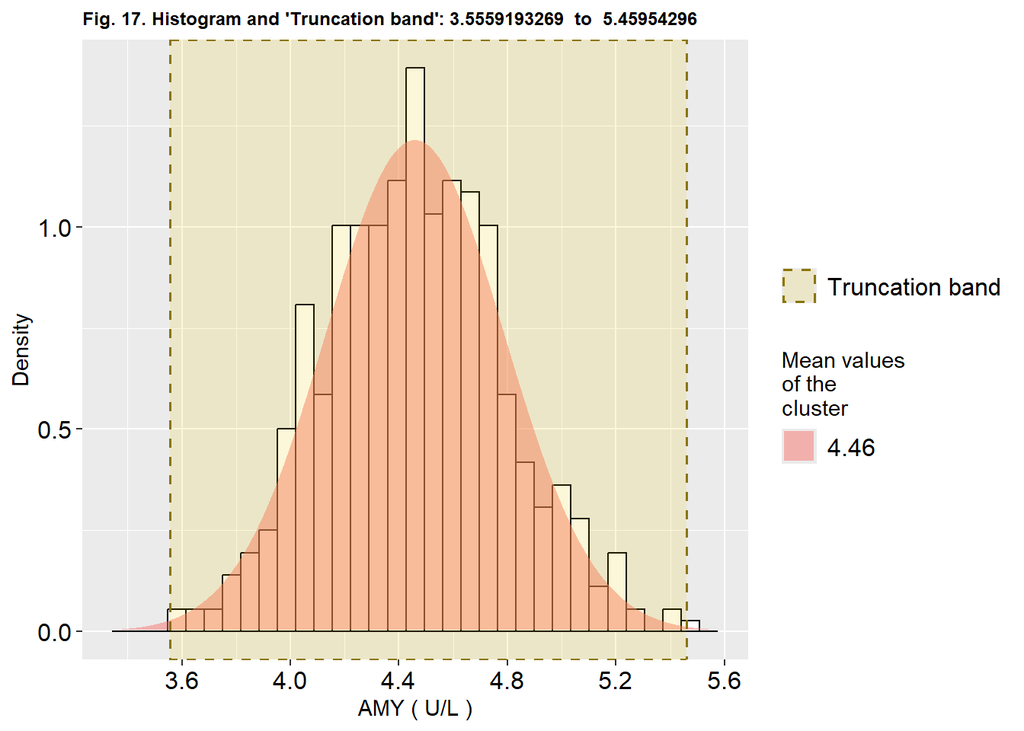

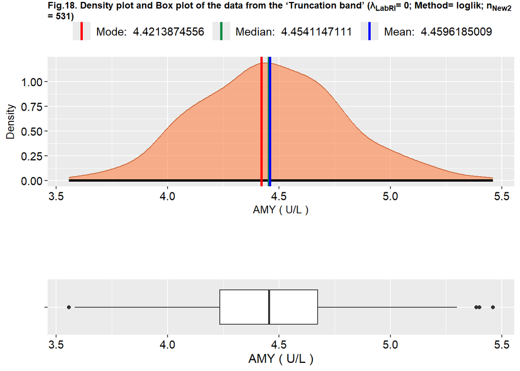

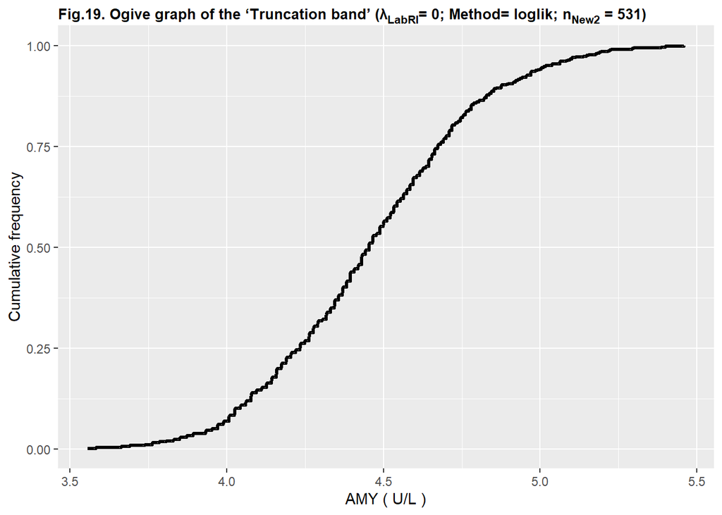

[interactive chart not shown]

| Statistical parameters | Results |
| --- | --- |
| N | 533 |
| n | 533 |
| n<sub>New1</sub> | 531 |
| n<sub>New2</sub> | 531 |
| Kt | 2.93 |
| Interpretation of the Kt | The distribution can be considered mesokurtic. |
| Sk<sub>Pearson</sub> | 0.14 |
| Interpreting the result of the Sk<sub>Pearson</sub> | Empirical relationship between Mean, Median, and Mode is: Mean > Median > Mode. The distribution is approximately symmetric. |

Footnote  
**N**, total sample size in the original dataset (before subsampling and outlier removal). **n**, number of observations effectively selected for analysis after subsampling. **n<sub>New1</sub>**, remaining sample size after outlier removal (number of observations retained for downstream analysis).**n<sub>New2</sub>**, remaining sample size after distribution truncation.**Kt**, Kurtosis coefficient. Sk<sub>Pearson</sub>, Pearson’s coefficient of skewness. **Mesokurtic:** If Kt is between 2.7 and 3.3, the distribution can be considered mesokurtic. **Platykurtic:** If Kt is less than 2.7. **Leptokurtic:** If Kt is greater than 3.3. **Distribution is highly skewed:** If Sk<sub>Pearson</sub> is less than -1 or greater than 1. **Distribution is moderately skewed:** If Sk<sub>Pearson</sub> is between -1 and -0.5 or between 0.5 and 1. **Distribution is slightly skewed:** If Sk<sub>Pearson</sub> is between -0.5 and -0.15 or between 0.15 and 0.5. **Distribution is approximately symmetrical:** If Sk<sub>Pearson</sub> is between -0.15 and 0.15. **References:** [[7]](https://doi.org/10.1515/CCLM.2010.319), [[8]](https://doi.org/10.1201/9781315153803), [[9]](https://doi.org/10.4103/aca.ACA_157_18), [[10]](https://doi.org/10.1016/j.clinbiochem.2019.06.006), [[11]](https://doi.org/10.1016/j.clinbiochem.2017.07.005)

**3.2.3. Cluster-driven reference interval estimation**

**3.2.3.1. Single-cluster scenario: EM-based reference interval estimation with empirical safeguard**

**Table 14.** EM-based reference interval estimates for the single-cluster truncated distribution.

| Algorithm used | RI<sub>optimized</sub>(parametric,non-parametric) |
| --- | --- |
| EM Algorithm | 47 to 165 |

Footnote  
**RI**, reference interval. **EM**, Expectation–Maximization.

**3.2.3.2. Multi-cluster scenario: consensus reference interval estimation with controlled winsorization**

**Table 15.** Consensus reference interval estimates using winsorized limits from refineR and reflimR, with EM-based estimates included when applicable (multi-cluster truncated distributions).

| Algorithm used | Before Winsorization RI before cleaning | Before Winsorization RI after cleaning | After Winsorization RI before cleaning | After Winsorization RI after cleaning | After Winsorization Centroid RI |
| --- | --- | --- | --- | --- | --- |
| RI refineR | Option disabled | Option disabled | Option disabled | Option disabled | Option disabled |
| RI reflimR | Option disabled | Option disabled | Option disabled | Option disabled |  |
| EM Algorithm | Option disabled | Option disabled | Option disabled | Option disabled |  |

Footnote  
**RI**, reference interval. **EM**, Expectation–Maximization (EM).